Ir al contenido

Ficha actualizada el 5 oct 2026

Ficha del establecimiento · RBD 9697

# Liceo Polivalente Lo Espejo

Lo EspejoLiceo Polivalente (HC + TP) + Educación de AdultosCon Programa de Integración EscolarJornada escolar completa

José Cristian Gutierrez Lillo

Dirección del establecimiento

🎒Matrícula

381

−39 respecto de 2025

📅Asistencia promedio

82,4 %

0,4 puntos bajo el promedio del SLEP

📇Estudiantes prioritarios

55,8 %

Concentración declarada (marzo)

📊SIMCE Lectura 2° medio

200 pts

−21 pts respecto del SLEP

¿Primera vez leyendo una ficha?Empieza por la ficha en cifras[Guía para leer los datos (se abre en otra pestaña)](https://datos.slepsantarosa.workers.dev/guia.html)

## La ficha en cifras

Cada cifra enlaza a su sección, donde está explicada y comparada con el SLEP.

📇Estudiantes prioritarios55,8 %Concentración declarada (marzo)Ver sección: Estudiantes prioritarios →

🎒Matrícula381−39 respecto de 2025Ver sección: Matrícula →

📅Asistencia promedio82,4 %0,4 puntos bajo el promedio del SLEPVer sección: Asistencia promedio →

🪑Ocupación de cursos55,7 %322 de 578 cupos declaradosVer sección: Ocupación de cursos →

🤝Estudiantes en el PIE6316,5 % de la matrículaVer sección: Estudiantes en el PIE →

🚶Retiros en 20266918,1 % de la matrículaVer sección: Retiros en 2026 →

📗Aprobación94,4 %Año escolar 2025Ver sección: Aprobación →

📊SIMCE Lectura 2° medio200 pts−21 pts respecto del SLEPVer sección: SIMCE Lectura 2° medio →

🏷️Categoría de desempeñoInsuficienteEducación media · 2019Ver sección: Categoría de desempeño →

💛Clima de convivencia escolar66,0De 0 a 100 · 2025Ver sección: Clima de convivencia escolar →

🧭Lectura en nivel satisfactorio17,0 %prácticamente igual que el promedio del SLEPVer sección: Lectura en nivel satisfactorio →

🎯PAES · competencia lectora496 pts−57 pts respecto del SLEPVer sección: PAES · competencia lectora →

🎓Titulados técnicos8Proceso 2025Ver sección: Titulados técnicos →

🏛️Egresados que siguen estudiando28,3 %Cohorte 2024Ver sección: Egresados que siguen estudiando →

🧰Egresados técnicos que siguen estudiando48,3 %Promoción 2024Ver sección: Egresados técnicos que siguen estudiando →

👥Funcionarios8251 docentes y 31 asistentes de la educaciónVer sección: Funcionarios →

📈Docentes en tramo avanzado o superior48 %21 de 44 con tramo asignadoVer sección: Docentes en tramo avanzado o superior →

📜Acciones del plan de mejoramiento23Plan 2025, en 4 dimensionesVer sección: Acciones del plan de mejoramiento →

⭐SNED 2026-2027No seleccionadoÍndice de 58,4 sobre 100Ver sección: SNED 2026-2027 →

🔗Convenios de uso de espacios3Organizaciones que usan sus espaciosVer sección: Convenios de uso de espacios →

🛡️Denuncias registradas3Última en 2025Ver sección: Denuncias registradas →

🚨Hechos delictuales registrados13Último en 20 may 2026Ver sección: Hechos delictuales registrados →

🗺️Niños y jóvenes en el barrio5.301De 0 a 17 años, a 800 m a la redondaVer sección: Niños y jóvenes en el barrio →

📍Estudiantes de la misma comuna64 %Viven en Lo EspejoVer sección: Estudiantes de la misma comuna →

Capítulo

¿Qué establecimiento es y qué ofrece?

## 🏫El establecimiento

- 📇Identificación y contacto
- 🎭Vida escolar y participación
- 🔧Especialidades técnico profesionales

El establecimiento · Identificación y contactoDatos al 5 oct 2026

### 📇Identificación y contacto

¿Qué establecimiento es y cómo contactarlo?

Liceo Polivalente (HC + TP) + Educación de Adultos en funcionamiento en Lo Espejo, imparte media humanístico-científica, enseñanza básica, media técnico-profesional artística, educación parvularia y atiende a 381 estudiantes.

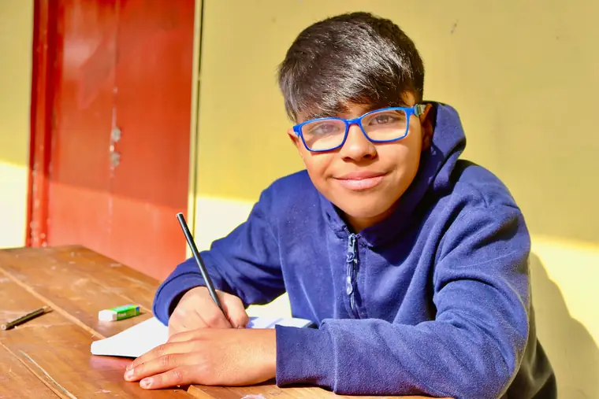

[figure not shown]

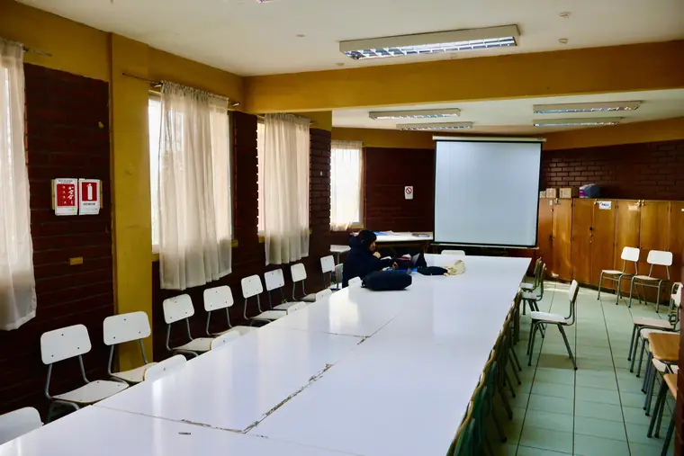

📷Fotografías del establecimiento

Concentración de estudiantes prioritarios

55,8 %

Estudiantes cuya situación socioeconómica puede afectar su rendimiento, según el Ministerio de Educación.

Índice de vulnerabilidad (IVE)

94,9 %

Su comuna: 88,5 %. Lo calcula la JUNAEB y decide a qué establecimientos llegan primero los programas de apoyo.

Cursos en funcionamiento

12

En media humanístico-científica y enseñanza básica y media técnico-profesional artística y educación parvularia

Programas y convenios

3

Programa de Integración Escolar · Programa PACE · Jornada Escolar Completa

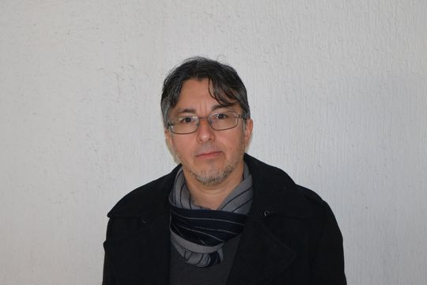

👤Dirección del establecimiento

José Cristian Gutierrez Lillo

✉️liceopolivalenteloespejo@slepsantarosa.cl

☎️443144718

🤝Asesoría técnica del SLEP: Diego Mendoza Cisternas

📍Dónde queda

Ines De Suarez 6970, Lo Espejo.

[interactive chart not shown]

Fuente: Coordenadas del directorio consolidado · [Abrir en Google Maps](https://www.google.com/maps/search/?api=1&query=-33.51331,-70.682958)

#### Identificación

**RBD**

9697

**Tipo de establecimiento**

Liceo Polivalente (HC + TP) + Educación de Adultos

**Dependencia**

Servicio Local de Educación Pública Santa Rosa

**Estado**

Funcionando

**Comuna**

Lo Espejo

#### Cómo contactarlo

**Dirección**

Ines De Suarez 6970

**Teléfono**

443144718

**Correo**

liceopolivalenteloespejo@slepsantarosa.cl

#### Equipo y apoyo técnico

**Dirección**

José Cristian Gutierrez Lillo

**Unidad Técnico Pedagógica**

utp.liceopolivalenteloespejo@slepsantarosa.cl

**Inspectoría**

inspectoria.liceopolivalenteloespejo@slepsantarosa.cl

**Asesoría técnica del SLEP**

Diego Mendoza Cisternas

#### Programas y convenios vigentes

Programa de Integración Escolar (PIE)Programa PACE (acceso a la educación superior)Jornada Escolar Completa

#### Apoyos profesionales al aprendizaje

ReforzamientoPsicologíaOrientaciónProfesor o profesora de educación especialTrabajo socialFonoaudiologíaPsicopedagogíaOrientación vocacional

#### Necesidades educativas que atiende

Tipos de necesidades educativas especiales que el establecimiento declara atender.

Discapacidad intelectualDificultades de aprendizajeTrastorno específico del lenguaje

#### Infraestructura declarada

Biblioteca (CRA)Laboratorio de cienciasComputación con internetSala audiovisualCancha deportivaAccesibilidad para NEEOtro: Auditorio, sala telecom. y psicomotricidad.Sala de usos múltiplesGimnasio techado

#### Documentos públicos

[Proyecto Educativo Institucional (PEI)](https://wwwfs.mineduc.cl/Archivos/infoescuelas/documentos/9697/ProyectoEducativo9697.pdf)[Reglamento de convivencia](https://wwwfs.mineduc.cl/Archivos/infoescuelas/documentos/9697/ReglamentodeConvivencia9697.pdf)[Reglamento de evaluación](https://wwwfs.mineduc.cl/Archivos/infoescuelas/documentos/9697/ReglamentoDeEvaluacion9697.pdf)

**¿Cómo se lee este dato?**

**Qué es**

La identificación oficial del establecimiento y las vías para comunicarse con él.

**De dónde sale**

Del directorio consolidado que el equipo actualiza cada mes con el registro oficial del Ministerio de Educación y los datos del propio Servicio Local.

**Cómo leerlo**

El **RBD** es el número con que el Ministerio identifica a cada establecimiento: sirve para buscarlo en cualquier sistema público. **Dependencia** indica quién lo administra; desde el traspaso, es el Servicio Local de Educación Pública.

**Referencia**

La **concentración de estudiantes prioritarios** es el porcentaje de estudiantes cuya situación socioeconómica puede dificultar su trayectoria escolar; el Ministerio la usa para asignar la subvención escolar preferencial.

**Lo que no dice**

Que un establecimiento tenga más programas no significa mejores resultados: son convenios a los que se postula según su proyecto y su matrícula.

**Para saber más**

[Guía para leer los datos: Cómo leer una ficha (se abre en otra pestaña)](https://datos.slepsantarosa.workers.dev/guia.html#empezar)

El establecimiento · Vida escolar y participación

### 🎭Vida escolar y participación

¿Quiénes participan en la comunidad educativa?

El establecimiento tiene centro de padres y apoderados, con personalidad jurídica vencida y cuenta con centro de estudiantes.

Centro de padres

Constituido

Personalidad jurídica: vencida

Centro de estudiantes

Constituido

Lo integran estudiantes del establecimiento

Consejo escolar

Con representante del sostenedor

Bruno Cortés González

#### Centro de padres y apoderados

**Personalidad jurídica**

Vencida

**Certificado de directorio vigente**

DPJ_POLIVALENTE.pdf

**Última elección del directorio**

**Próxima elección**

Para contactarlo, escribe al establecimiento: sus datos están en «Identificación y contacto».

#### Centro de estudiantes

El establecimiento tiene centro de estudiantes constituido. Lo integran estudiantes del propio establecimiento.

#### Consejo escolar

**Representante del sostenedor**

Bruno Cortés González

**Acompañamiento del SLEP**

Eiden Viera Pardo

**Observaciones**

Con personalidad jurídica desactualizada, sin directiva activa

**¿Cómo se lee este dato?**

**Qué es**

Las tres instancias de participación que la ley exige a cada establecimiento: el **consejo escolar** (donde se encuentran dirección, docentes, asistentes, apoderados y estudiantes), el **centro de padres** y el **centro de estudiantes**.

**De dónde sale**

Del registro que mantiene el Servicio Local con los establecimientos, actualizado cuando hay elecciones o cambios de directiva.

**Cómo leerlo**

La **personalidad jurídica** permite al centro de padres administrar recursos propios. Un centro sin directorio vigente no puede firmar convenios ni recibir aportes.

**Lo que no dice**

Que una instancia figure constituida no dice cuán activa es: el registro solo guarda su estado formal.

El establecimiento · Especialidades TPDatos de agosto de 2026

### 🔧Especialidades técnico profesionales

¿Qué especialidades técnicas ofrece?

En agosto de 2026 el establecimiento imparte 2 especialidades técnicas, donde estudian 65 de sus 381 estudiantes (17,1 % de la matrícula).

Especialidades que imparte

2

En 2 sectores económicos

Estudiantes en formación técnica

65

17,1 % de la matrícula del establecimiento

Aprobación en las especialidades

90,9 %

−1,5 pts respecto de 2024 (92,4 %)

#### Atención de párvulos

**Sector económico**

Programas y Proyectos Sociales

**Estudiantes**

35

**Cursos**

2

#### Telecomunicaciones

**Sector económico**

Electricidad

**Estudiantes**

30

**Cursos**

2

Atención de párvulos concentra 54 % de la matrícula técnica

Estudiantes matriculados en cada especialidad en agosto de 2026. Solo cursan especialidad los estudiantes de 3° y 4° medio.

[interactive chart not shown]

Fuente: SIGE, MINEDUC.

**¿Cómo se lee este dato?**

**Qué es**

La formación diferenciada técnico profesional son los dos últimos años de la enseñanza media: en 3° y 4° medio cada estudiante elige una especialidad y, además de las asignaturas comunes, cursa los módulos de esa especialidad. Al egresar obtiene la licencia de enseñanza media y, después de aprobar su práctica profesional, el título de técnico de nivel medio.

**De dónde sale**

De la matrícula mensual del Sistema de Información General de Estudiantes (SIGE), que registra la especialidad de cada curso, y de las actas de rendimiento por especialidad.

**Cómo leerlo**

El sector económico agrupa especialidades afines —Alimentación, Metalmecánico, Administración y Comercio— y es el que define la familia de títulos a la que pertenece cada una. Mira cuántos estudiantes tiene cada especialidad antes de comparar sus resultados: en un grupo de 15 personas, dos reprobados mueven la cifra más de 10 puntos.

**Referencia**

En 2024 la enseñanza media técnico profesional del país promovió al 93,9 % de sus estudiantes, frente al 95,8 % de la humanista-científica.

**Lo que no dice**

Tener más especialidades no significa mejor formación: la oferta depende del equipamiento, de los convenios con empresas y de la demanda del territorio. Tampoco dice cuántos estudiantes se titularon: eso está en Titulación técnico profesional.

**Para saber más**

[Guía para leer los datos: Rendimiento (se abre en otra pestaña)](https://datos.slepsantarosa.workers.dev/guia.html#rendimiento)

**Ver el detalle por especialidad y curso (2025)**

Rendimiento por especialidad y curso

| Especialidad | Curso | Estudiantes | Aprobación | Promedio de notas |
| --- | --- | --- | --- | --- |
| Atención de párvulos | 3° Medio | 9 | 88,9 % | 5,6 |
| Atención de párvulos | 4° Medio | 13 | 100,0 % | 6,1 |
| Telecomunicaciones | 3° Medio | 16 | 75,0 % | 5,1 |
| Telecomunicaciones | 4° Medio | 17 | 100,0 % | 5,5 |

Capítulo

¿A quiénes educa y cómo avanzan durante el año?

## 🧒Estudiantes

- 🎒Matrícula
- 📅Asistencia
- 🪑Ocupación de cursos
- 🤝Programa de Integración Escolar (PIE)
- 🚶Retiros y traslados

Estudiantes · MatrículaDatos de agosto de 2026

### 🎒Matrícula

¿Cuántos estudiantes tiene y cómo ha cambiado?

En agosto de 2026 estudian 381 estudiantes en el establecimiento, 39 menos que en 2025.

Estudiantes matriculados

381

−39 estudiantes respecto de 2025 (−9,3 %)

82

SLEP 300381

915Rango de los establecimientos del SLEP

Estudiantes por curso

31,8

12 cursos en funcionamiento

10,5

SLEP 30,631,8

50,9Rango de los establecimientos del SLEP

Estudiantes extranjeros

31,0 %

118 de 381 estudiantes

6,5 %

SLEP 29,8 %31,0 %

77,6 %Rango de los establecimientos del SLEP

La matrícula bajó 9,3 % en el último año

Estudiantes matriculados en agosto de cada año, según el registro mensual del SIGE.

[interactive chart not shown]

Fuente: SIGE, MINEDUC.

**¿Cómo se lee este dato?**

**Qué es**

La cantidad de estudiantes inscritos en el establecimiento en el mes de corte.

**De dónde sale**

Del Sistema de Información General de Estudiantes (SIGE), que cada establecimiento actualiza mes a mes.

**Cómo leerlo**

Mira la tendencia de varios años antes que un mes aislado: la matrícula se mueve todo el año por traslados, retiros y nuevas incorporaciones.

**Lo que no dice**

Que un establecimiento tenga más estudiantes no significa que enseñe mejor: el tamaño depende de la infraestructura, de los cupos declarados y del barrio.

**Para saber más**

[Guía para leer los datos: Matrícula (se abre en otra pestaña)](https://datos.slepsantarosa.workers.dev/guia.html#matricula)

**Ver la matrícula curso por curso (21 cursos)**

Matrícula por curso

| Curso | Estudiantes | % del total |
| --- | --- | --- |
| Pre-kínder A | 9 | 2,4 % |
| Kínder A | 6 | 1,6 % |
| 1° Básico A | 11 | 2,9 % |
| 2° Básico A | 16 | 4,2 % |
| 3° Básico A | 12 | 3,1 % |
| 4° Básico A | 15 | 3,9 % |
| 5° Básico A | 27 | 7,1 % |
| 6° Básico A | 18 | 4,7 % |
| 7° Básico A | 15 | 3,9 % |
| 8° Básico A | 20 | 5,2 % |
| 1° Medio A | 30 | 7,9 % |
| 1° Medio B | 30 | 7,9 % |
| 2° Medio A | 24 | 6,3 % |
| 2° Medio B | 24 | 6,3 % |
| 3° Medio A | 27 | 7,1 % |
| 3° Medio B | 18 | 4,7 % |
| 4° Medio A | 8 | 2,1 % |
| 4° Medio B | 12 | 3,1 % |
| 1° Nivel (Adultos) A | 20 | 5,2 % |
| 2° Nivel (Adultos) A | 15 | 3,9 % |
| 2° Nivel (Adultos) B | 24 | 6,3 % |

Estudiantes · AsistenciaDatos de agosto de 2026

### 📅Asistencia

¿Cuántos estudiantes van a clases todos los días?

De marzo a agosto de 2026, los estudiantes asistieron en promedio 82,4 % de los días con clases: 0,4 puntos bajo el promedio del SLEP (82,8 %).

Asistencia promedio del año

82,4 %

+3,4 puntos respecto de 2025

49,4 %

SLEP 82,8 %82,4 %

90,4 %Rango de los establecimientos del SLEP

Asistencia de agosto

83,8 %

381 estudiantes en 21 cursos

49,3 %

SLEP 83,6 %83,8 %

93,4 %Rango de los establecimientos del SLEP

Curso con menor asistencia

75,8 %

3° Medio A · 6,6 puntos bajo el promedio del establecimiento

5 de 6 meses quedan bajo el 85 %, el más bajo en julio

Asistencia promedio del establecimiento en cada mes de 2026, ponderada por la matrícula de cada curso.

[interactive chart not shown]

Fuente: SIGE, MINEDUC.

**¿Cómo se lee este dato?**

**Qué es**

La proporción entre los días que un estudiante va a clases y los días que hubo clases. La asistencia de un curso o de un establecimiento es el promedio de esos porcentajes.

**De dónde sale**

El establecimiento registra la asistencia todos los días y la declara cada mes en el Sistema de Información General de Estudiantes (SIGE). Esa misma asistencia es la base de la subvención.

**Cómo leerlo**

Compara cada mes con el mismo mes del año anterior: marzo y diciembre se leen distinto por el ingreso escalonado y el cierre del año.

**Referencia**

El Decreto 67 de 2018 exige al menos 85 % de asistencia en el año para ser promovido, con excepciones que autoriza la dirección. El Centro de Estudios del Ministerio usa cuatro categorías: destacada (97 % o más), normal (90 a 97 %), inasistencia reiterada (85 a 90 %) e inasistencia grave (85 % o menos).

**Lo que no dice**

Cuántos estudiantes faltan mucho. Un promedio alto puede esconder a varios estudiantes bajo el 85 %: para saberlo hay que mirar caso a caso, no el promedio.

**Para saber más**

[Guía para leer los datos: Asistencia (se abre en otra pestaña)](https://datos.slepsantarosa.workers.dev/guia.html#asistencia)

**Ver la asistencia curso por curso (21 cursos)**

Asistencia por curso, marzo a agosto de 2026

| Curso | Estudiantes | Asistencia del año | Situación |
| --- | --- | --- | --- |
| Pre-kínder A | 10 | 86,4 % | Sobre el umbral |
| Kínder A | 6 | 84,0 % | Bajo el umbral |
| 1° Básico A | 11 | 83,0 % | Bajo el umbral |
| 2° Básico A | 16 | 83,1 % | Bajo el umbral |
| 3° Básico A | 12 | 83,5 % | Bajo el umbral |
| 4° Básico A | 15 | 82,2 % | Bajo el umbral |
| 5° Básico A | 29 | 81,0 % | Bajo el umbral |
| 6° Básico A | 18 | 84,7 % | Bajo el umbral |
| 7° Básico A | 14 | 85,2 % | Sobre el umbral |
| 8° Básico A | 21 | 83,6 % | Bajo el umbral |
| 1° Medio A | 29 | 80,7 % | Bajo el umbral |
| 1° Medio B | 30 | 81,4 % | Bajo el umbral |
| 2° Medio A | 25 | 80,5 % | Bajo el umbral |
| 2° Medio B | 25 | 79,0 % | Bajo el umbral |
| 3° Medio A | 29 | 75,8 % | Bajo el umbral |
| 3° Medio B | 21 | 82,8 % | Bajo el umbral |
| 4° Medio A | 8 | 80,5 % | Bajo el umbral |
| 4° Medio B | 12 | 82,1 % | Bajo el umbral |
| 1° Nivel (Adultos) A | 20 | 90,2 % | Sobre el umbral |
| 2° Nivel (Adultos) A | 15 | 85,3 % | Sobre el umbral |
| 2° Nivel (Adultos) B | 17 | 86,3 % | Sobre el umbral |

Estudiantes · Ocupación de cursosDatos de agosto de 2026

### 🪑Ocupación de cursos

¿Cuántos cupos están ocupados en cada curso?

En agosto de 2026, 322 estudiantes ocupan los 578 cupos que el establecimiento declaró al Sistema de Admisión Escolar (SAE): 55,7 % de ocupación, con 256 cupos disponibles.

Ocupación de los cupos declarados

55,7 %

322 estudiantes en 578 cupos

33,3 %

SLEP 68,3 %55,7 %

111,2 %Rango de los establecimientos del SLEP

Cursos sobre su capacidad declarada

0

de 18 cursos con cupos declarados

Cupos disponibles

256

repartidos en 18 cursos

En este establecimiento hay 3 cursos sin cupos declarados al SAE: no entran en el cálculo de la ocupación.

Quedan 256 cupos disponibles, repartidos en 18 cursos

Estudiantes matriculados en agosto de 2026 (barra azul) sobre los cupos que el establecimiento declaró al SAE (barra gris).

[interactive chart not shown]

Fuente: SIGE y Sistema de Admisión Escolar, MINEDUC.

**¿Cómo se lee este dato?**

**Qué es**

La ocupación compara los estudiantes efectivamente matriculados en cada curso con los cupos que el establecimiento declaró al Sistema de Admisión Escolar (SAE).

**De dónde sale**

Los cupos los declara el propio establecimiento en el proceso del SAE; la matrícula sale del registro mensual del SIGE. Las dos cifras viajan en la misma tabla, curso por curso.

**Cómo leerlo**

El 100 % significa que todos los cupos declarados están tomados. Pasar del 100 % quiere decir que hay más estudiantes que cupos: casi siempre es señal de que la capacidad declarada al SAE quedó desactualizada, no de que sobren estudiantes en la sala.

**Referencia**

No hay un umbral oficial: la referencia es la capacidad declarada (100 %). Entre los 53 establecimientos del SLEP que declaran cupos, la ocupación va de 33,3 % a 111,2 %, con un promedio de 68,3 %.

**Lo que no dice**

Cuánto espacio físico real tiene el establecimiento. Un curso puede aparecer con cupos libres porque se reservaron vacantes para el SAE o porque la capacidad declarada es mayor que la que se usa.

**Para saber más**

[Guía para leer los datos: Matrícula (se abre en otra pestaña)](https://datos.slepsantarosa.workers.dev/guia.html#matricula)

**Ver los cupos curso por curso (21 cursos)**

Cupos declarados y matrícula por curso, agosto de 2026

| Curso | Estudiantes | Cupos declarados | Ocupación | Cupos disponibles |
| --- | --- | --- | --- | --- |
| Pre-kínder A | 9 | 25 | 36,0 % | 16 |
| Kínder A | 6 | 25 | 24,0 % | 19 |
| 1° Básico A | 11 | 30 | 36,7 % | 19 |
| 2° Básico A | 16 | 30 | 53,3 % | 14 |
| 3° Básico A | 12 | 30 | 40,0 % | 18 |
| 4° Básico A | 15 | 30 | 50,0 % | 15 |
| 5° Básico A | 27 | 30 | 90,0 % | 3 |
| 6° Básico A | 18 | 30 | 60,0 % | 12 |
| 7° Básico A | 15 | 30 | 50,0 % | 15 |
| 8° Básico A | 20 | 30 | 66,7 % | 10 |
| 1° Medio A | 30 | 36 | 83,3 % | 6 |
| 1° Medio B | 30 | 36 | 83,3 % | 6 |
| 2° Medio A | 24 | 36 | 66,7 % | 12 |
| 2° Medio B | 24 | 36 | 66,7 % | 12 |
| 3° Medio A | 27 | 36 | 75,0 % | 9 |
| 3° Medio B | 18 | 36 | 50,0 % | 18 |
| 4° Medio A | 8 | 36 | 22,2 % | 28 |
| 4° Medio B | 12 | 36 | 33,3 % | 24 |
| 1° Nivel (Adultos) A | 20 | — | — | — |
| 2° Nivel (Adultos) A | 15 | — | — | — |
| 2° Nivel (Adultos) B | 24 | — | — | — |

Estudiantes · PIEDatos de abril de 2026

### 🤝Programa de Integración Escolar (PIE)

¿Cuántos estudiantes reciben apoyos del Programa de Integración Escolar?

63 estudiantes reciben apoyos del Programa de Integración Escolar: 16,5 % de la matrícula, 2,3 puntos bajo el promedio del SLEP (18,8 %).

Estudiantes en el PIE

63

de 381 estudiantes matriculados en agosto de 2026

3

SLEP 5363

140Rango de los establecimientos del SLEP

Porcentaje de la matrícula

16,5 %

−2,3 puntos respecto del promedio del SLEP (18,8 %)

1,7 %

SLEP 18,8 %16,5 %

34,2 %Rango de los establecimientos del SLEP

Diagnóstico más frecuente

16estudiantes

Lenguaje (TEL) · 25 % de quienes están en el PIE

El PIE bajó de 104 a 94 estudiantes entre 2024 y 2026

Estudiantes con necesidades educativas especiales registrados cada año por el Área de Inclusión Educativa del SLEP. Es un catastro distinto de la nómina del SIGE que alimenta las cifras clave, por eso los totales no coinciden exactamente.

[interactive chart not shown]

Fuente: PIE Territorial, Área de Inclusión Educativa del SLEP Santa Rosa.

**¿Cómo se lee este dato?**

**Qué es**

El Programa de Integración Escolar (PIE) entrega apoyos adicionales —profesionales de apoyo, horas de trabajo conjunto con los docentes y materiales— a los estudiantes que tienen una necesidad educativa especial (NEE) diagnosticada, dentro de la misma sala de clases.

**De dónde sale**

El detalle por estudiante sale de la nómina PIE del SIGE (abril de 2026) y la serie por año, del catastro del Área de Inclusión Educativa del SLEP. Son dos registros distintos, con fechas distintas: sus totales no calzan exactamente.

**Cómo leerlo**

Una necesidad «permanente» acompaña a la persona durante toda su vida —por ejemplo una discapacidad intelectual, sensorial o motora— y da derecho a apoyos en toda la trayectoria escolar. Una necesidad «transitoria» se presenta en un período de la escolaridad y se espera que se supere con apoyo, como las dificultades del aprendizaje o del lenguaje. En la mayoría de los establecimientos las transitorias son las más numerosas.

**Referencia**

En el SLEP Santa Rosa el promedio es 18,8 % de la matrícula. El programa se rige por el Decreto 170 del Ministerio de Educación, que define qué diagnósticos puede atender y qué apoyos financia.

**Lo que no dice**

Un porcentaje alto de estudiantes en el PIE no es un mal resultado: habla de cuántos estudiantes tienen apoyos reconocidos y financiados, no de cómo enseña el establecimiento. Tampoco dice cuántos estudiantes necesitan apoyo, porque solo cuenta a quienes ya tienen un diagnóstico vigente y entraron al programa.

**Ver el detalle por diagnóstico (6 diagnósticos)**

Estudiantes del PIE por diagnóstico

| Diagnóstico | Tipo de necesidad | Estudiantes | % del PIE |
| --- | --- | --- | --- |
| Lenguaje (TEL) | Transitoria | 16 | 25,4 % |
| Funcionamiento limítrofe | Transitoria | 15 | 23,8 % |
| Discapacidad intelectual | Permanente | 13 | 20,6 % |
| Dificultades del aprendizaje | Transitoria | 10 | 15,9 % |
| Espectro autista (TEA) | Permanente | 8 | 12,7 % |
| Déficit atencional (TDA) | Transitoria | 1 | 1,6 % |

Estudiantes · Retiros y trasladosDatos de agosto de 2026

### 🚶Retiros y traslados

¿Cuántos estudiantes se fueron durante el año y por qué?

En 2026 se registraron 69 retiros: 18,1 % de la matrícula, 4,4 puntos sobre el promedio del SLEP (13,7 %).

De los 69 retiros de 2026, 7 son cambios de curso dentro del mismo establecimiento: el SIGE los anota como un retiro y una matrícula nueva, aunque el estudiante nunca se fue. Estudiantes que efectivamente dejaron el establecimiento: 62.

Retiros registrados en 2026

69

−40 respecto del mismo período de 2025 (109 retiros)

1

SLEP 3969

155Rango de los establecimientos del SLEP

Porcentaje de la matrícula

18,1 %

+4,4 puntos respecto del promedio del SLEP (13,7 %)

0,6 %

SLEP 13,7 %18,1 %

103,3 %Rango de los establecimientos del SLEP

Movimiento más frecuente

28retiros

Sin matrícula posterior · 41 % de los retiros del año

Abril concentró la mayor cantidad de retiros: 18 de 69

Retiros registrados cada mes de 2026, desde marzo hasta agosto.

[interactive chart not shown]

Fuente: Registro de retiros y traslados del SIGE, MINEDUC.

**¿Cómo se lee este dato?**

**Qué es**

Un retiro es el registro que hace el establecimiento en el SIGE cuando un estudiante deja su curso durante el año escolar. No todos los retiros son iguales: la mayoría son traslados, es decir, el estudiante se matricula en otro establecimiento y sigue estudiando.

**De dónde sale**

Del registro de retiros y traslados del SIGE, cruzado con la matrícula vigente para saber dónde quedó cada estudiante. El corte de estos datos es agosto de 2026.

**Cómo leerlo**

Distingue el «traslado a otro establecimiento» —el estudiante sigue en el sistema escolar, dentro o fuera del SLEP— del «retiro sin matrícula posterior», que es el que conviene mirar de cerca, porque puede anticipar una desvinculación del sistema. Los meses de marzo y diciembre concentran movimientos administrativos —regularizaciones de inicio de año y cierres de curso—, así que un alza en esos meses no significa lo mismo que un alza en mitad del año.

**Referencia**

En el SLEP Santa Rosa los retiros equivalen en promedio a 13,7 % de la matrícula en lo que va de 2026. La comparación se hace con el mismo corte para todos los establecimientos.

**Lo que no dice**

El retiro no es lo mismo que la deserción: solo la matrícula del año siguiente confirma si un estudiante dejó de estudiar. Y como el año todavía no termina, la cifra seguirá subiendo hasta diciembre: no se puede comparar con el total de un año cerrado.

**Para saber más**

[Guía para leer los datos: Matrícula (se abre en otra pestaña)](https://datos.slepsantarosa.workers.dev/guia.html#matricula)

**Ver el detalle mes a mes por tipo de movimiento**

Retiros de 2026 por mes y tipo de movimiento

| Mes del retiro | Sin matrícula | Fuera del SLEP | Dentro del SLEP | Cambio interno | Total |
| --- | --- | --- | --- | --- | --- |
| marzo | 4 | 4 | 4 | 1 | 13 |
| abril | 11 | 5 | 0 | 2 | 18 |
| mayo | 3 | 7 | 1 | 2 | 13 |
| junio | 3 | 2 | 3 | 0 | 8 |
| julio | 6 | 5 | 1 | 0 | 12 |
| agosto | 1 | 1 | 1 | 2 | 5 |

**Ver a qué establecimientos se trasladaron (22 establecimientos)**

Establecimientos de destino de los estudiantes trasladados

| Establecimiento de destino | Comuna | Estudiantes |
| --- | --- | --- |
| Liceo Politecnico Part.sagrado Corazon | Lo Espejo | 5 |
| Liceo Técnico Clotario Blest Riffo | Pedro Aguirre Cerda | 3 |
| Centro Duc.cardenal José María Caro | Lo Espejo | 2 |
| Colegio Parque Las Americas | Pedro Aguirre Cerda | 2 |
| Colegio San Lucas De Lo Espejo | Lo Espejo | 2 |
| Colegio Sol De Chile | Lo Espejo | 2 |
| Liceo Politecnico San Luis | San Miguel | 2 |
| Liceo Teniente Francisco Mery Aguirre | Lo Espejo | 2 |
| C.e.i.a.pedro Aguirre Cerda | Pedro Aguirre Cerda | 1 |
| Colegio Alma Mater | La Granja | 1 |
| Colegio Corazones De Jesus | Lo Espejo | 1 |
| Colegio Educad Lo Espejo | Lo Espejo | 1 |
| Colegio Poliv. San Bernardo Abad | San Bernardo | 1 |
| Complejo Educacional San Alfonso | Puente Alto | 1 |
| Esc. Bas. Patr. Willins Hoover Kurt | La Cisterna | 1 |
| Escuela Bas. Oscar Encalada Yovanovich | La Cisterna | 1 |
| Escuela La Victoria | Pedro Aguirre Cerda | 1 |
| Escuela Las Palmas | Puente Alto | 1 |
| Instituto Comercial Padre Alberto Hurtado De Pedro Aguirre Cerda | Pedro Aguirre Cerda | 1 |
| Liceo Bicentenario Politecnico Manuel Montt | Victoria | 1 |
| Liceo Ignacio Carrera Pinto | San Vicente | 1 |
| Liceo Polivalente Eugenio Pereira Salas | Pedro Aguirre Cerda | 1 |

Capítulo

¿Qué están aprendiendo sus estudiantes?

## 📚Aprendizajes

- 📗Rendimiento
- 📊SIMCE
- 🏷️Categoría de desempeño
- 💛Desarrollo personal y social
- 🧭Diagnóstico Integral de Aprendizajes (DIA)
- 🎯PAES
- 🎓Titulación técnico profesional

Aprendizajes · RendimientoDatos de año escolar 2025

### 📗Rendimiento

¿Cuántos estudiantes aprobaron el año?

En 2025, 94,4 % de los estudiantes que terminaron el año fue promovido de curso, 2,2 puntos por debajo que el promedio del SLEP.

Estudiantes promovidos

94,4 %

−1,5 puntos respecto de 2024

49,7 %

SLEP 96,5 %94,4 %

100,0 %Rango de los establecimientos del SLEP

Nota promedio del establecimiento

5,5

Promedio general de todos los cursos

5,4

SLEP 5,95,5

6,3Rango de los establecimientos del SLEP

Reprobados por inasistencia

8

De 22 estudiantes reprobados en 2025

La aprobación bajó 1,5 puntos respecto de 2024

Porcentaje de estudiantes promovidos sobre los que terminaron el año en el establecimiento (no incluye retirados ni trasladados).

[interactive chart not shown]

Fuente: Actas de rendimiento, SIGE.

**¿Cómo se lee este dato?**

**Qué es**

El resultado del año escolar de cada estudiante: promovido al curso siguiente o reprobado.

**De dónde sale**

De las actas de rendimiento que el establecimiento entrega al Ministerio al cerrar el año, a través del SIGE.

**Cómo leerlo**

La aprobación se calcula sobre quienes **terminaron el año** en el establecimiento. Los estudiantes **retirados** o **trasladados** se cuentan aparte (sección Retiros y traslados), porque su resultado final lo registra otro establecimiento.

**Referencia**

Un estudiante puede reprobar por notas o por asistencia inferior al 85 % sin justificación aceptada por la dirección.

**Lo que no dice**

Una aprobación de 100 % no significa por sí sola que todos aprendieron lo esperado: para eso están los resultados del SIMCE y del DIA.

**Para saber más**

[Guía para leer los datos: Rendimiento (se abre en otra pestaña)](https://datos.slepsantarosa.workers.dev/guia.html#rendimiento)

**Ver el detalle por curso**

Rendimiento por curso

| Curso | Evaluados | Promovidos | Reprobados | Aprobación | Nota promedio |
| --- | --- | --- | --- | --- | --- |
| 1° Básico | 19 | 19 | 0 | 100,0 % | 5,9 |
| 2° Básico | 15 | 14 | 1 | 93,3 % | 6,0 |
| 3° Básico | 16 | 16 | 0 | 100,0 % | 6,2 |
| 4° Básico | 28 | 28 | 0 | 100,0 % | 6,2 |
| 5° Básico | 17 | 16 | 1 | 94,1 % | 5,6 |
| 6° Básico | 13 | 13 | 0 | 100,0 % | 6,0 |
| 7° Básico | 23 | 23 | 0 | 100,0 % | 5,9 |
| 8° Básico | 29 | 29 | 0 | 100,0 % | 5,8 |
| 1° Medio | 65 | 56 | 9 | 86,2 % | 5,1 |
| 2° Medio | 60 | 59 | 1 | 98,3 % | 5,4 |
| 3° Medio | 25 | 20 | 5 | 80,0 % | 5,3 |
| 4° Medio | 30 | 30 | 0 | 100,0 % | 5,8 |
| 1° Nivel (Adultos) | 19 | 17 | 2 | 89,5 % | 5,3 |
| 2° Nivel (Adultos) | 31 | 28 | 3 | 90,3 % | 5,2 |

Aprendizajes · SIMCEDatos de 2025

### 📊SIMCE

¿Cómo les fue en las pruebas nacionales SIMCE?

En 2025, 2° medio obtuvo 200 pts en Lectura, 21 puntos por debajo de el promedio del SLEP.

Lectura · 2° medio

200 pts

−18 pts respecto de 2024

188

SLEP 221200

255Rango de los establecimientos del SLEP

Matemática · 2° medio

213 pts

+7 pts respecto de 2024

203

SLEP 225213

259Rango de los establecimientos del SLEP

Lectura · 4° básico

222 pts

−40 pts respecto de 2024

200

SLEP 258222

314Rango de los establecimientos del SLEP

Evolución de los puntajes en 2° medio

Puntaje promedio del establecimiento en cada aplicación del SIMCE. No hubo SIMCE en 2020 ni 2021.

[interactive chart not shown]

Fuente: Agencia de Calidad de la Educación.

Para 2025 la Agencia de Calidad publicó los puntajes pero no cuántos estudiantes rindieron la prueba en este establecimiento. Por eso los promedios del SLEP de ese año son simples, no ponderados por matrícula evaluada.

**¿Cómo se lee este dato?**

**Qué es**

El SIMCE es la prueba nacional que aplica la Agencia de Calidad para saber qué aprendieron los estudiantes en Lectura, Matemática y, en algunos años, Ciencias.

**De dónde sale**

De los resultados oficiales que publica la Agencia de Calidad de la Educación por establecimiento y grado.

**Cómo leerlo**

Un puntaje aislado dice poco: compáralo con el promedio del SLEP (la barra de cada tarjeta) y con los años anteriores del mismo curso. Los estándares —**Insuficiente**, **Elemental** y **Adecuado**— dicen cuántos estudiantes alcanzaron lo esperado, que suele ser más informativo que el promedio.

**Referencia**

Diferencias menores a 5 puntos entre años no son significativas: dependen de qué estudiantes rindieron la prueba ese año.

**Lo que no dice**

El SIMCE no mide todo lo que hace una escuela: no evalúa artes, deportes, convivencia ni el progreso individual de cada estudiante.

**Para saber más**

[Guía para leer los datos: SIMCE (se abre en otra pestaña)](https://datos.slepsantarosa.workers.dev/guia.html#simce)

**Ver todos los resultados**

Resultados SIMCE por año, curso y asignatura

| Año | Curso | Asignatura | Puntaje | Evaluados |
| --- | --- | --- | --- | --- |
| 2025 | 2° medio | Lectura | 200 | sin dato |
| 2025 | 2° medio | Matemática | 213 | sin dato |
| 2025 | 4° básico | Lectura | 222 | sin dato |
| 2025 | 4° básico | Matemática | 218 | sin dato |
| 2025 | 8° básico | Lectura | 202 | sin dato |
| 2025 | 8° básico | Matemática | 217 | sin dato |
| 2024 | 2° medio | Lectura | 218 | 28 |
| 2024 | 2° medio | Matemática | 206 | 29 |
| 2024 | 4° básico | Lectura | 262 | 15 |
| 2024 | 4° básico | Matemática | 249 | 16 |
| 2024 | 6° básico | Lectura | 245 | 11 |
| 2024 | 6° básico | Matemática | 237 | 12 |
| 2023 | 2° medio | Lectura | 221 | 29 |
| 2023 | 2° medio | Matemática | 207 | 31 |
| 2023 | 4° básico | Lectura | 273 | 11 |
| 2023 | 4° básico | Matemática | 246 | 11 |
| 2022 | 2° medio | Lectura | 203 | 27 |
| 2022 | 2° medio | Matemática | 224 | 24 |
| 2022 | 4° básico | Lectura | 236 | 11 |
| 2022 | 4° básico | Matemática | 234 | 11 |
| 2018 | 2° medio | Ciencias Naturales | 183 | 25 |
| 2018 | 2° medio | Lectura | 208 | 18 |
| 2018 | 2° medio | Matemática | 176 | 17 |
| 2018 | 4° básico | Lectura | 233 | 15 |
| 2018 | 4° básico | Matemática | 207 | 14 |
| 2017 | 2° medio | Historia y Ciencias Sociales | 195 | 24 |
| 2017 | 2° medio | Lectura | 203 | 19 |
| 2017 | 2° medio | Matemática | 179 | 20 |
| 2016 | 2° medio | Ciencias Naturales | 197 | 21 |
| 2016 | 2° medio | Lectura | 206 | 20 |
| 2016 | 2° medio | Matemática | 185 | 21 |

Aprendizajes · Categoría de desempeñoDatos de 2019

### 🏷️Categoría de desempeño

¿Cómo clasifica la Agencia de Calidad a este establecimiento?

En 2019 la Agencia de Calidad clasificó al establecimiento como Insuficiente en educación media. En educación básica no pudo clasificarlo por falta de información.

La Agencia de Calidad ordena a todos los establecimientos del país en cuatro categorías. No mira solo el SIMCE: combina los puntajes con los indicadores de desarrollo personal y social, con el contexto socioeconómico de los estudiantes y con cuánto avanzó el establecimiento respecto de sí mismo. La categoría define qué apoyo recibe del Estado.

Educación básica

Sin categoría

Ese año no hubo suficientes estudiantes evaluados para clasificarlo. Clasificación de 2019.

Educación media

Insuficiente

En 2018 era insuficiente.

Cómo ha cambiado la clasificación

Categoría asignada en cada año con clasificación publicada. El color del punto repite la categoría: verde Alto, azul Medio, amarillo Medio-bajo, rojo Insuficiente.

[interactive chart not shown]

Fuente: Agencia de Calidad de la Educación.

#### El historial completo

Categoría de desempeño por año y nivel

| Año | Nivel | Categoría |
| --- | --- | --- |
| 2019 | Básica | Sin categoría |
| 2019 | Media | Insuficiente |
| 2018 | Media | Insuficiente |
| 2017 | Media | Insuficiente |

La última clasificación en las bases del equipo es de 2019. Mientras la Agencia no publique una nueva, esa sigue siendo la categoría vigente del establecimiento.

**«Sin categoría» no es una mala evaluación**: significa que ese año el establecimiento no tenía suficientes estudiantes evaluados para que la Agencia pudiera clasificarlo. Por eso esos años no aparecen en el gráfico.

**¿Cómo se lee este dato?**

**Qué es**

La clasificación oficial que la Agencia de Calidad hace de cada establecimiento del país, una vez al año.

**De dónde sale**

De las ordenaciones que publica la Agencia de Calidad de la Educación, por establecimiento y nivel de enseñanza.

**Cómo leerlo**

Las cuatro categorías, de mayor a menor, son **Alto**, **Medio**, **Medio-bajo** e **Insuficiente**. Se comparan establecimientos de contexto socioeconómico parecido, así que la categoría no es lo mismo que el puntaje SIMCE: una escuela puede tener puntajes bajos y aun así quedar en Medio si avanza más que las escuelas con las que se la compara.

**Referencia**

Las categorías **Medio-bajo** e **Insuficiente** obligan a la Agencia a acompañar al establecimiento con apoyo técnico. Mantenerse en Insuficiente durante cuatro años seguidos puede terminar en la pérdida del reconocimiento oficial.

**Lo que no dice**

La categoría no mide el trabajo de un profesor ni de un curso: es del establecimiento completo y se calcula con datos de varios años, así que refleja una trayectoria, no el año en curso.

**Para saber más**

[Guía para leer los datos: Categoría de Desempeño (se abre en otra pestaña)](https://datos.slepsantarosa.workers.dev/guia.html#categoria-desempeno)

Aprendizajes · Desarrollo personal y socialDatos de 2025

### 💛Desarrollo personal y social

¿Cómo se sienten los estudiantes en su establecimiento?

Entre 2016 y 2025 la Agencia midió estos indicadores 7 veces. El mayor cambio de la última fue hábitos de vida saludable, que subió 8,2 puntos respecto de 2024 (de 57,5 a 65,7 de 100).

Autoestima académica y motivación escolar

70,3de 100

1,3 puntos más que en 2024

Bajo el contexto similar

Clima de convivencia escolar

66,0de 100

1,0 punto menos que en 2024

Bajo el contexto similar

Participación y formación ciudadana

71,0de 100

4,5 puntos más que en 2024

Bajo el contexto similar

Hábitos de vida saludable

65,7de 100

8,2 puntos más que en 2024

Bajo el contexto similar

Cómo cambió cada indicador entre 2016 y 2025

Puntaje promedio del establecimiento en cada aplicación, de 0 a 100. Años con datos: 2016, 2017, 2018, 2022, 2023, 2024 y 2025. No hubo medición en 2019, 2020 y 2021. El eje vertical va de 55 a 80 puntos, no parte en cero, para que se vea el movimiento.

[interactive chart not shown]

Fuente: Agencia de Calidad de la Educación · cuestionarios SIMCE.

En 2025, lo más alto fue participación y formación ciudadana y lo más bajo, hábitos de vida saludable

Puntaje de 0 a 100. La barra azul es el establecimiento; la gris, el promedio de los establecimientos de contexto socioeconómico similar que usa la Agencia para comparar. En 2025 quedó sobre ese promedio en 0 de los 4 indicadores y bajo en 4.

[interactive chart not shown]

Fuente: Agencia de Calidad de la Educación · cuestionarios SIMCE.

**¿Cómo se lee este dato?**

**Qué es**

Cuatro indicadores que miden cómo viven los estudiantes su escuela: autoestima académica y motivación, clima de convivencia, participación y formación ciudadana, y hábitos de vida saludable.

**De dónde sale**

De los cuestionarios que responden estudiantes, familias y docentes junto con el SIMCE. Los calcula la Agencia de Calidad.

**Cómo leerlo**

Van de 0 a 100 y no son notas: 100 sería que todas las respuestas apuntan en la dirección deseada. En el gráfico de evolución, cada línea es un indicador y su color lo identifica; el eje vertical está recortado al rango de los datos para que el movimiento se vea, y se corta en los años sin aplicación. En el gráfico del último año el color dice quién es, no si el resultado es bueno: azul el establecimiento, gris el promedio de establecimientos de contexto socioeconómico similar; la etiqueta de cada tarjeta dice con palabras si el establecimiento quedó sobre, bajo o igual que ese promedio, y una diferencia menor a medio punto se lee como «igual». En 2025 se evaluó más de un curso, así que el puntaje es el promedio de esos cursos y por eso lleva un decimal. Sin ese decimal, clima de convivencia escolar (66,0) y hábitos de vida saludable (65,7) se leerían los dos como 66.

**Referencia**

Estos indicadores pesan un tercio de la Categoría de Desempeño que asigna la Agencia de Calidad. La comparación con establecimientos de contexto similar viene en las bases de 2024 y 2025.

**Lo que no dice**

No miden la convivencia del año en curso: reflejan lo que respondieron las personas el año de la evaluación. Tampoco son un seguimiento de los mismos estudiantes: cada aplicación mide a los cursos que rindieron el SIMCE ese año, que no siempre son los mismos, así que parte del cambio entre años viene de qué cursos se evaluaron.

**Para saber más**

[Guía para leer los datos: Categoría de Desempeño (se abre en otra pestaña)](https://datos.slepsantarosa.workers.dev/guia.html#categoria-desempeno)

**Ver el detalle por año y curso**

Indicadores de desarrollo personal y social

| Año | Curso | Indicador | Puntaje | Contexto similar | Diferencia |
| --- | --- | --- | --- | --- | --- |
| 2025 | 2m | Autoestima académica y motivación escolar | 72,0 | 74,0 | −2 |
| 2025 | 4b | Autoestima académica y motivación escolar | 71,0 | 76,0 | −5 |
| 2025 | 8b | Autoestima académica y motivación escolar | 68,0 | 74,0 | −6 |
| 2025 | 2m | Clima de convivencia escolar | 66,0 | 75,0 | −9 |
| 2025 | 4b | Clima de convivencia escolar | 62,0 | 76,0 | −14 |
| 2025 | 8b | Clima de convivencia escolar | 70,0 | 75,0 | −5 |
| 2025 | 2m | Participación y formación ciudadana | 71,0 | 77,0 | −6 |
| 2025 | 4b | Participación y formación ciudadana | 72,0 | 80,0 | −8 |
| 2025 | 8b | Participación y formación ciudadana | 70,0 | 78,0 | −8 |
| 2025 | 2m | Hábitos de vida saludable | 67,0 | 72,0 | −5 |
| 2025 | 4b | Hábitos de vida saludable | 66,0 | 71,0 | −5 |
| 2025 | 8b | Hábitos de vida saludable | 64,0 | 72,0 | −8 |
| 2024 | 2m | Autoestima académica y motivación escolar | 66,0 | 74,0 | −8 |
| 2024 | 4b | Autoestima académica y motivación escolar | 72,0 | 75,0 | −3 |
| 2024 | 2m | Clima de convivencia escolar | 67,0 | 75,0 | −8 |
| 2024 | 4b | Clima de convivencia escolar | 67,0 | 75,0 | −8 |
| 2024 | 2m | Participación y formación ciudadana | 65,0 | 76,0 | −11 |
| 2024 | 4b | Participación y formación ciudadana | 68,0 | 79,0 | −11 |
| 2024 | 2m | Hábitos de vida saludable | 62,0 | 72,0 | −10 |
| 2024 | 4b | Hábitos de vida saludable | 53,0 | 71,0 | −18 |
| 2023 | 2m | Autoestima académica y motivación escolar | 73,0 | — | — |
| 2023 | 4b | Autoestima académica y motivación escolar | 77,0 | — | — |
| 2023 | 2m | Clima de convivencia escolar | 77,0 | — | — |
| 2023 | 4b | Clima de convivencia escolar | 74,0 | — | — |
| 2023 | 2m | Participación y formación ciudadana | 78,0 | — | — |
| 2023 | 4b | Participación y formación ciudadana | 78,0 | — | — |
| 2023 | 2m | Hábitos de vida saludable | 67,0 | — | — |
| 2023 | 4b | Hábitos de vida saludable | 74,0 | — | — |
| 2022 | 2m | Autoestima académica y motivación escolar | 70,0 | — | — |
| 2022 | 4b | Autoestima académica y motivación escolar | 65,0 | — | — |
| 2022 | 2m | Clima de convivencia escolar | 78,0 | — | — |
| 2022 | 4b | Clima de convivencia escolar | 73,0 | — | — |
| 2022 | 2m | Participación y formación ciudadana | 81,0 | — | — |
| 2022 | 4b | Participación y formación ciudadana | 69,0 | — | — |
| 2022 | 2m | Hábitos de vida saludable | 68,0 | — | — |
| 2022 | 4b | Hábitos de vida saludable | 66,0 | — | — |
| 2018 | 2m | Autoestima académica y motivación escolar | 70,1 | — | — |
| 2018 | 4b | Autoestima académica y motivación escolar | 70,7 | — | — |
| 2018 | 2m | Clima de convivencia escolar | 68,6 | — | — |
| 2018 | 4b | Clima de convivencia escolar | 66,0 | — | — |
| 2018 | 2m | Participación y formación ciudadana | 73,4 | — | — |
| 2018 | 4b | Participación y formación ciudadana | 74,4 | — | — |
| 2018 | 2m | Hábitos de vida saludable | 57,1 | — | — |
| 2018 | 4b | Hábitos de vida saludable | 60,9 | — | — |
| 2017 | 2m | Autoestima académica y motivación escolar | 72,7 | — | — |
| 2017 | 8b | Autoestima académica y motivación escolar | 75,4 | — | — |
| 2017 | 2m | Clima de convivencia escolar | 70,4 | — | — |
| 2017 | 8b | Clima de convivencia escolar | 72,5 | — | — |
| 2017 | 2m | Participación y formación ciudadana | 71,1 | — | — |
| 2017 | 8b | Participación y formación ciudadana | 80,1 | — | — |
| 2017 | 2m | Hábitos de vida saludable | 58,6 | — | — |
| 2017 | 8b | Hábitos de vida saludable | 63,1 | — | — |
| 2016 | 2m | Autoestima académica y motivación escolar | 72,0 | — | — |
| 2016 | 2m | Clima de convivencia escolar | 71,0 | — | — |
| 2016 | 2m | Participación y formación ciudadana | 78,0 | — | — |
| 2016 | 2m | Hábitos de vida saludable | 66,0 | — | — |

Aprendizajes · Diagnóstico Integral de Aprendizajes (DIA)Datos al 29 sep 2026

### 🧭Diagnóstico Integral de Aprendizajes (DIA)

¿Qué aprendizajes lograron durante el año según el DIA?

En el monitoreo intermedio 2026, 19,9 % de los 206 estudiantes evaluados en Lectura quedó en el nivel más bajo (Nivel I, insatisfactorio): 0,5 puntos bajo el promedio del SLEP.

El DIA es una herramienta de la Agencia de Calidad de la Educación que el propio establecimiento aplica, de forma voluntaria y para uso interno, en tres momentos del año: diagnóstico en marzo, monitoreo intermedio en julio y cierre en noviembre. No es una prueba de ranking ni entra en la evaluación oficial del establecimiento: sirve para ver cómo van los estudiantes y ajustar la enseñanza durante el año.

Este establecimiento tiene resultados del DIA en 10 períodos: Monitoreo intermedio 2026, Diagnóstico 2026, Cierre 2025, Monitoreo intermedio 2025, Diagnóstico 2025, Inicio 2025, Cierre 2024, Monitoreo intermedio 2024, Diagnóstico 2024, Inicio 2024. Cada aplicación es una foto propia y se lee por separado.

Lectura en nivel satisfactorio

17,0 %

prácticamente igual que el promedio del SLEP

0 %

SLEP 17 %17 %

53 %Rango de los establecimientos del SLEP

Matemática en nivel satisfactorio

21,4 %

8,1 puntos sobre el promedio del SLEP

0 %

SLEP 13 %21 %

44 %Rango de los establecimientos del SLEP

Lectura en nivel insatisfactorio

19,9 %

0,5 puntos bajo el promedio del SLEP

5 %

SLEP 20 %20 %

55 %Rango de los establecimientos del SLEP

NT1: consolidando o profundizando

0,0 %

10,9 puntos bajo el promedio del SLEP

#### Las pruebas por asignatura: cómo le fue a cada grado

En estas pruebas los estudiantes responden preguntas de la asignatura y la Agencia informa cómo queda el grupo. En las pestañas están Lectura, Matemática, Escritura, Historia y Cs. Sociales, Ciencias Naturales. Elige un período en las pestañas.

En Lectura, 63 % de los estudiantes evaluados quedó en el nivel intermedio (Nivel II)

Monitoreo intermedio 2026: cómo se reparten los estudiantes de cada grado entre los niveles de logro, con el total del establecimiento y el promedio del SLEP para la misma prueba y los mismos grados. Áreas evaluadas: Lectura y Matemática y Ciencias Naturales.

[interactive chart not shown]

Fuente: Agencia de Calidad de la Educación · DIA monitoreo intermedio 2026, aplicado del 7 de julio al 28 de agosto de 2026 (plazo extendido).

En 11 grados evaluados hay menos de 10 estudiantes con resultado (por ejemplo, 6 estudiantes en Historia y Cs. Sociales de 6° básico, monitoreo intermedio 2025): en grupos así un solo estudiante mueve el porcentaje varios puntos. No todos los períodos evalúan las mismas asignaturas: Monitoreo intermedio 2026, Diagnóstico 2026, Monitoreo intermedio 2025 cubren menos asignaturas que el período más completo, así que las pestañas no son directamente comparables entre sí. Las pestañas muestran los 4 períodos más recientes; Diagnóstico 2025, Cierre 2024, Monitoreo intermedio 2024, Diagnóstico 2024 están en las tablas de detalle.

#### Los cuestionarios: qué responden los propios estudiantes

Los cuestionarios del DIA no son pruebas y no tienen respuestas correctas: son afirmaciones que responden los propios estudiantes, en la sala, sobre cómo se sienten y cómo ven su establecimiento. No los responden los apoderados ni los docentes. Aquí los respondieron estudiantes de 4° básico a IV° medio.

El porcentaje que se informa es el de respuestas favorables: las que expresan una percepción positiva de lo que la pregunta plantea. Mientras más alto, más estudiantes del grupo respondieron en ese sentido. Es la percepción del curso en ese momento, no un diagnóstico de cada estudiante. En los temas de ansiedad las preguntas están redactadas al revés a propósito: ahí un porcentaje alto significa menos ansiedad.

#### Condiciones para la formación integral

Lo respondieron 235 estudiantes de 4° básico a IV° medio, en el monitoreo intermedio 2026.

Les pregunta por su bienestar en el establecimiento, cuánta ansiedad les producen las evaluaciones y qué apoyo reciben, y por sus habilidades para convivir en internet.

#### Aprendizaje socioemocional

Lo respondieron 262 estudiantes de 4° básico a IV° medio, en el diagnóstico 2026.

Les pregunta cómo se conocen y se manejan a sí mismos, cómo se relacionan con los demás y cómo participan en la comunidad escolar.

#### Convivencia escolar

Lo respondieron 264 estudiantes de 4° básico a IV° medio, en el diagnóstico 2026.

Les pregunta cómo viven la convivencia en su curso y en el establecimiento, qué apoyo recibe quien lo necesita y qué pasa cuando hay problemas graves.

En Condiciones para la formación integral, los estudiantes responden mejor sobre Bienestar (69 % de respuestas favorables) y más bajo sobre Ansiedad ante las evaluaciones (37 %)

Porcentaje de respuestas favorables de los propios estudiantes en cada tema, junto al promedio de los establecimientos del SLEP en el mismo cuestionario. Cada barra junta las preguntas sobre los estudiantes y las preguntas sobre lo que hace el establecimiento. Aplicaciones más recientes de cada cuestionario: Condiciones para la formación integral (monitoreo intermedio 2026), Aprendizaje socioemocional (diagnóstico 2026), Convivencia escolar (diagnóstico 2026).

[interactive chart not shown]

Fuente: Agencia de Calidad de la Educación · cuestionarios del DIA respondidos por los estudiantes.

#### DIA de Educación Parvularia: NT1 y NT2

En NT1 y NT2 no hay prueba: la educadora observa a cada niño y niña durante varias semanas y registra en qué nivel de progreso está en cada núcleo de aprendizaje, con las rúbricas que entrega la Agencia.

En NT2 (kínder), 73 % de las evaluaciones por núcleo está en Consolidando o Profundizando

Inicio 2025: cómo se reparten las evaluaciones de cada núcleo de aprendizaje entre los cuatro niveles de progreso, en NT1 y NT2, con el promedio del SLEP. Cada niño o niña es evaluado en todos los núcleos.

[interactive chart not shown]

Fuente: Agencia de Calidad de la Educación · DIA de Educación Parvularia.

**¿Cómo se lee este dato?**

**Qué es**

El Diagnóstico Integral de Aprendizajes (DIA) muestra cómo van los estudiantes en Lectura, Matemática, Escritura, Historia, Ciencias Naturales y en el área socioemocional. Tiene tres partes distintas. Las pruebas por asignatura informan la distribución del curso en tres niveles de logro (Nivel I o insatisfactorio, Nivel II o intermedio, Nivel III o satisfactorio) y el porcentaje de respuestas correctas por eje y habilidad. Los cuestionarios los responden los propios estudiantes, de 4.º básico a IV.º medio —no los apoderados ni los docentes—, y se informan como porcentaje de respuestas favorables por tema; incluyen preguntas sobre ellos mismos y preguntas sobre lo que hace el establecimiento, que también contestan ellos. El DIA de Educación Parvularia no es una prueba: la educadora observa a cada niño y niña y registra su nivel de progreso en cuatro categorías (Comenzando, Desarrollando, Consolidando y Profundizando).

**De dónde sale**

Lo aplica el propio establecimiento con los instrumentos que entrega la Agencia de Calidad de la Educación, en tres momentos: diagnóstico (marzo y abril), monitoreo intermedio (julio y agosto) y cierre (fines de octubre a inicios de diciembre). Las cifras vienen de las bases que procesa el Departamento de Estudios, Monitoreo y Datos del SLEP con los informes de la Agencia, las mismas del Visor DIA del portal.

**Cómo leerlo**

Mira primero cuántos estudiantes rindieron cada aplicación: si en marzo rindieron 28 y en noviembre 22, la comparación pierde fuerza. Después mira la distribución completa, no solo el nivel más alto: dos cursos con el mismo promedio pueden tener proporciones muy distintas en Nivel I. Los ejes y habilidades de la tabla de detalle dicen qué contenidos avanzaron y cuáles no. Lo que responden los estudiantes en los cuestionarios se lee como percepción, no como diagnóstico clínico.

**Referencia**

El promedio del SLEP que aparece junto a cada barra es el resultado de los establecimientos del servicio en la misma prueba, el mismo período y los mismos grados. Es contexto para conversar, no un ranking ni una meta oficial.

**Lo que no dice**

Hasta dónde llega: cada período es una foto propia y no se encadena con los demás. Las únicas comparaciones que respalda la Agencia son monitoreo intermedio contra cierre del mismo año en lo académico, y diagnóstico contra cierre del mismo año en lo socioemocional. El diagnóstico mide los aprendizajes del año anterior; los instrumentos de 2026 cambiaron con el fin de la priorización curricular y no se comparan con 2025; el Cierre 2024 viene agregado por establecimiento; y el DIA de Educación Parvularia no se compara entre años ni entre NT1 y NT2. El DIA tampoco se compara con el SIMCE ni con el DIA de otro establecimiento.

**Para saber más**

[Guía para leer los datos: DIA (se abre en otra pestaña)](https://datos.slepsantarosa.workers.dev/guia.html#dia)